# Linear regression model to predict house prices in USA

### PROJECT NAME: A LINEAR REGRESSION MODEL TO PREDICT HOUSE PRICES IN THE USA USING MACHINE LEARNING

### BY: JACKTONE ETEMESI

#### EMAIL: jacktoneetemesi1@gmail.com

Introduction

This notebook file contains the code for a linear regression model for predicting the price of houses in the USA based on the following attributes:

- Average income earned by people in the area
- Average age of houses in the area
- Average number of rooms in houses within the area
- Average number of bedrooms in houses within the area
- Population of the area.

Data Source:

The data used in this analysis was collected and compiled by GANTALA SWETHA and can be found on this [Link:](https://www.kaggle.com/code/gantalaswetha/usa-housing-dataset-linear-regression)

```python
# importing relevant libraries
import numpy as np
import pandas as pd
import matplotlib.pyplot as plt
import seaborn as sns
%matplotlib inline
```

```python
# importing data

df=pd.read_csv('USA_Housing.csv',sep=',')
```

## Exploratory Data Analysis

Under this section, we will take a peek into our dataset to understand it better. We will do this by exploring the following:

1. Variable names
2. Variables data types
3. Some descriptive statistics on numerical columns
4. Correlation between variables

```python
df.head()
```

|  | Avg. Area Income | Avg. Area House Age | Avg. Area Number of Rooms | Avg. Area Number of Bedrooms | Area Population | Price | Address |
| --- | --- | --- | --- | --- | --- | --- | --- |
| 0 | 79545.458574 | 5.682861 | 7.009188 | 4.09 | 23086.800503 | 1.059034e+06 | 208 Michael Ferry Apt. 674\nLaurabury, NE 3701... |
| 1 | 79248.642455 | 6.002900 | 6.730821 | 3.09 | 40173.072174 | 1.505891e+06 | 188 Johnson Views Suite 079\nLake Kathleen, CA... |
| 2 | 61287.067179 | 5.865890 | 8.512727 | 5.13 | 36882.159400 | 1.058988e+06 | 9127 Elizabeth Stravenue\nDanieltown, WI 06482... |
| 3 | 63345.240046 | 7.188236 | 5.586729 | 3.26 | 34310.242831 | 1.260617e+06 | USS Barnett\nFPO AP 44820 |
| 4 | 59982.197226 | 5.040555 | 7.839388 | 4.23 | 26354.109472 | 6.309435e+05 | USNS Raymond\nFPO AE 09386 |

```python
df.columns
```

```
Index(['Avg. Area Income', 'Avg. Area House Age', 'Avg. Area Number of Rooms',
       'Avg. Area Number of Bedrooms', 'Area Population', 'Price', 'Address'],
      dtype='object')
```

```python
df.info()
```

```
<class 'pandas.core.frame.DataFrame'>
RangeIndex: 5000 entries, 0 to 4999
Data columns (total 7 columns):
 #   Column                        Non-Null Count  Dtype
---  ------                        --------------  -----
 0   Avg. Area Income              5000 non-null   float64
 1   Avg. Area House Age           5000 non-null   float64
 2   Avg. Area Number of Rooms     5000 non-null   float64
 3   Avg. Area Number of Bedrooms  5000 non-null   float64
 4   Area Population               5000 non-null   float64
 5   Price                         5000 non-null   float64
 6   Address                       5000 non-null   object
dtypes: float64(6), object(1)
memory usage: 273.6+ KB
```

```python
df.describe()
```

|  | Avg. Area Income | Avg. Area House Age | Avg. Area Number of Rooms | Avg. Area Number of Bedrooms | Area Population | Price |
| --- | --- | --- | --- | --- | --- | --- |
| count | 5000.000000 | 5000.000000 | 5000.000000 | 5000.000000 | 5000.000000 | 5.000000e+03 |
| mean | 68583.108984 | 5.977222 | 6.987792 | 3.981330 | 36163.516039 | 1.232073e+06 |
| std | 10657.991214 | 0.991456 | 1.005833 | 1.234137 | 9925.650114 | 3.531176e+05 |
| min | 17796.631190 | 2.644304 | 3.236194 | 2.000000 | 172.610686 | 1.593866e+04 |
| 25% | 61480.562388 | 5.322283 | 6.299250 | 3.140000 | 29403.928702 | 9.975771e+05 |
| 50% | 68804.286404 | 5.970429 | 7.002902 | 4.050000 | 36199.406689 | 1.232669e+06 |
| 75% | 75783.338666 | 6.650808 | 7.665871 | 4.490000 | 42861.290769 | 1.471210e+06 |
| max | 107701.748378 | 9.519088 | 10.759588 | 6.500000 | 69621.713378 | 2.469066e+06 |

```python
# checking for nulls
df.isnull().sum()
```

```
Avg. Area Income                0
Avg. Area House Age             0
Avg. Area Number of Rooms       0
Avg. Area Number of Bedrooms    0
Area Population                 0
Price                           0
Address                         0
dtype: int64
```

```python
#checking for duplicate values
df.duplicated().sum()
```

```
0
```

```python
# checking for Multicollinearity between our variables
df.corr()
```

|  | Avg. Area Income | Avg. Area House Age | Avg. Area Number of Rooms | Avg. Area Number of Bedrooms | Area Population | Price |
| --- | --- | --- | --- | --- | --- | --- |
| Avg. Area Income | 1.000000 | -0.002007 | -0.011032 | 0.019788 | -0.016234 | 0.639734 |
| Avg. Area House Age | -0.002007 | 1.000000 | -0.009428 | 0.006149 | -0.018743 | 0.452543 |
| Avg. Area Number of Rooms | -0.011032 | -0.009428 | 1.000000 | 0.462695 | 0.002040 | 0.335664 |
| Avg. Area Number of Bedrooms | 0.019788 | 0.006149 | 0.462695 | 1.000000 | -0.022168 | 0.171071 |
| Area Population | -0.016234 | -0.018743 | 0.002040 | -0.022168 | 1.000000 | 0.408556 |
| Price | 0.639734 | 0.452543 | 0.335664 | 0.171071 | 0.408556 | 1.000000 |

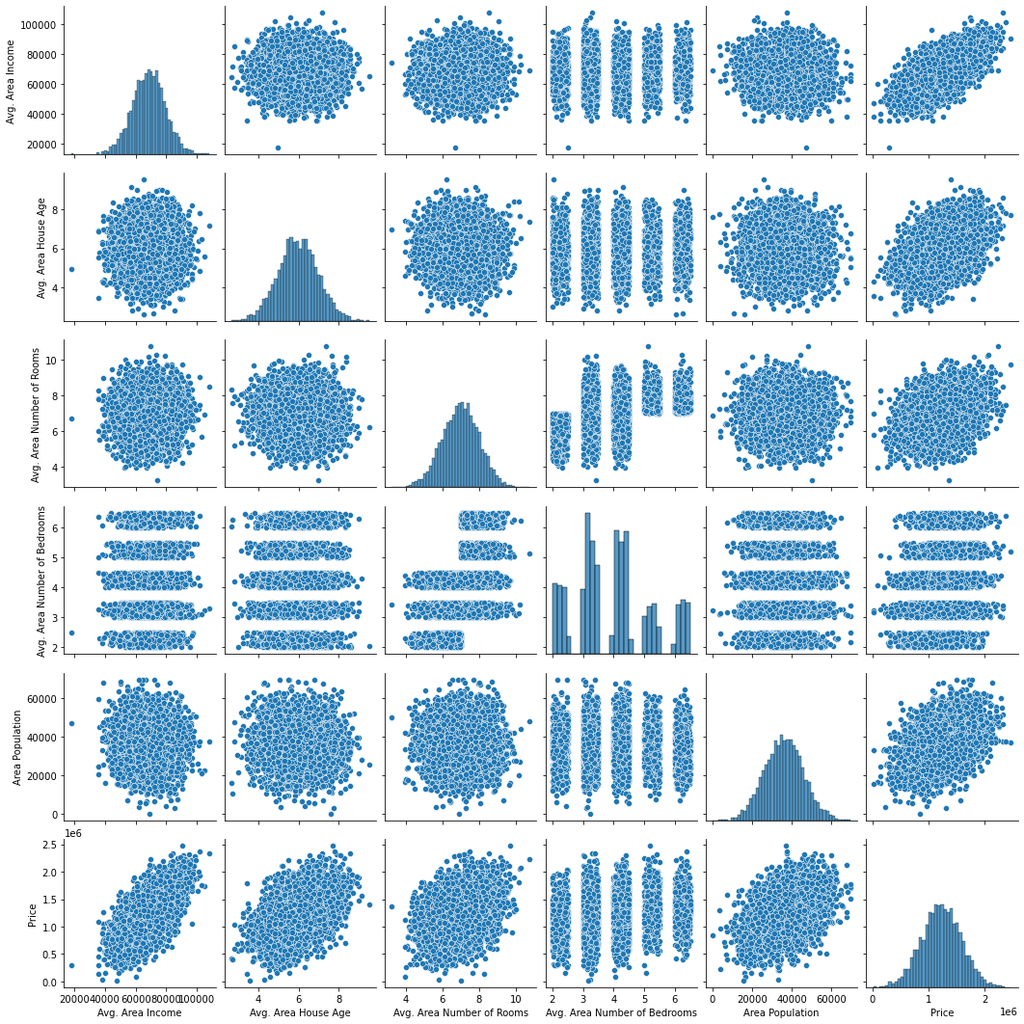

```python
# visualizing the correlation
sns.pairplot(df)
```

## Fitting and Training our model

```python
from sklearn.model_selection import train_test_split

# defining dependent and independent variables

x=df[df.columns[:-2]]
y=df['Price']

# splitting data into train an test data

x_train,x_test,y_train,y_test=train_test_split(x,y,train_size=0.40,random_state=101)

# fitting data

from sklearn.linear_model import LinearRegression

lmodel=LinearRegression()

lmodel.fit(X=x_train,y=y_train)

# training our model

predictions=lmodel.predict(x_test)

# extracting coefficients

from sklearn import metrics

mae=metrics.mean_absolute_error(y_test,predictions)
mse=metrics.mean_squared_error(y_test,predictions)
mrte=np.sqrt(mse)
r_value=metrics.explained_variance_score(y_test,predictions)

# formulating coefficient matrix

coeff=lmodel.coef_

intercept=lmodel.intercept_

coeff_matrix=pd.DataFrame(data=coeff,index=df.columns[0:-2],columns=['Coefficients'])
```

#### checking for correlation between predicted and observed y values

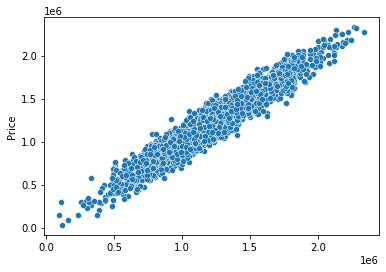

```python
sns.scatterplot(x=predictions,y=y_test)
```

There is a strong correlation between our Predicted and observed Y values indicating that our model has a high confidence interval.

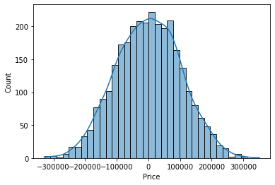

```python
# plotting for distribution of residuals

sns.histplot(y_test-predictions,kde=True)
```

Residuals, i.e the difference between observed and predicted y values has a normal distribution indicating a well balanced model. Our model coefficients are as follows:

```python
coeff_matrix
```

|  | Coefficients |
| --- | --- |
| Avg. Area Income | 21.384444 |
| Avg. Area House Age | 162975.483408 |
| Avg. Area Number of Rooms | 121802.121132 |
| Avg. Area Number of Bedrooms | 1934.163056 |
| Area Population | 15.189607 |

From the coefficient matrix above, it is observed that Avg.Area house age greatly contributes to the price of a house followed by number of rooms. By assigning these coefficients alphabet characters a,b,c,d,e we get the following coefficient matrix.

```python
symbols='a b c d e'.split(' ')
coeff_matrix['symbol']=symbols
coeff_matrix
```

|  | Coefficients | symbol |
| --- | --- | --- |
| Avg. Area Income | 21.384444 | a |
| Avg. Area House Age | 162975.483408 | b |
| Avg. Area Number of Rooms | 121802.121132 | c |
| Avg. Area Number of Bedrooms | 1934.163056 | d |
| Area Population | 15.189607 | e |